# Case 5 · The Average Day Doesn't Exist

## Investigating global explanations of bike-rental predictions

**The manager's question:** “What does our model rely on—and what does its average explanation hide?”

You are auditing a bike-sharing prediction model for an operations manager. The goal is not just to produce explanation plots, but to ask what each plot represents, what assumptions it makes, and what evidence could make its interpretation misleading.

Two investigations drive the case:

- **Hour of day** shows how individual responses can disappear behind an average.
- **Temperature** shows how feature-effect curves can depend on the inputs we ask the model to evaluate.

By the end, you should be able to distinguish **predictive reliance (PFI)**, **average responses (PDP)**, **individual responses (ICE)**, and **accumulated local changes (ALE)**, and to inspect whether explanation queries resemble observed data.

## 1 · What are we predicting?

The data contains system-wide hourly rental counts and recorded calendar/weather conditions from Capital Bikeshare. **One row is one hour**, not one rider or station. Our target is `cnt`, total rentals recorded in that hour.

This is an **offline audit using recorded conditions**. A future forecast would need weather information available at forecast time. The data does not establish unmet demand, rider motives, or station-level relocation decisions.

**Predict first:** if `casual` and `registered` count two types of rentals, what would happen if we used both to predict `cnt`?

```python
from pathlib import Path
import hashlib
import json
import platform
import time
import numpy as np
import pandas as pd
import matplotlib
import matplotlib.pyplot as plt
import sklearn
from IPython.display import display, Markdown
from sklearn.compose import ColumnTransformer
from sklearn.preprocessing import OneHotEncoder
from sklearn.pipeline import make_pipeline
from sklearn.ensemble import RandomForestRegressor
from sklearn.metrics import mean_absolute_error, root_mean_squared_error, r2_score
from sklearn.neighbors import NearestNeighbors

START = time.perf_counter()
SEED = 2026
ROOT = Path.cwd()
if not (ROOT / 'data/hour.csv').is_file():
    raise FileNotFoundError('Open the extracted case5_bike_rentals_global_explanations folder and run from beside data/hour.csv.')
OUTPUTS = ROOT / 'outputs'
OUTPUTS.mkdir(exist_ok=True)
plt.rcParams.update({'font.size': 11, 'axes.spines.top': False,
                     'axes.spines.right': False, 'figure.dpi': 110})
TEAL, ORANGE, INK = '#24798b', '#c7793c', '#223344'

def show_figure(fig, name):
    fig.savefig(OUTPUTS / f'{name}.png', dpi=160, bbox_inches='tight')
    plt.show()
    plt.close(fig)

versions = {'python': platform.python_version(), 'numpy': np.__version__,
            'pandas': pd.__version__, 'scikit-learn': sklearn.__version__,
            'matplotlib': matplotlib.__version__}
display(pd.Series(versions, name='Runtime version').to_frame())
```

|  | Runtime version |
| --- | --- |
| python | 3.13.7 |
| numpy | 2.5.3 |
| pandas | 3.0.6 |
| scikit-learn | 1.9.1 |
| matplotlib | 3.11.2 |

```python
data_file = ROOT / 'data/hour.csv'
data_hash = hashlib.sha256(data_file.read_bytes()).hexdigest()
assert data_hash == 'e03de4ee4ef4dc376ac6e04bf829673c6269e8eba5c60fa121640fa2f829504f', 'Dataset differs from the tested source.'
data = pd.read_csv(data_file)
timestamp = pd.to_datetime(data['dteday']) + pd.to_timedelta(data['hr'], unit='h')
assert timestamp.is_monotonic_increasing and not timestamp.duplicated().any()
assert (data['cnt'] == data['casual'] + data['registered']).all()
absent_hours = int((timestamp.max() - timestamp.min()).total_seconds()/3600 + 1 - len(data))
display(pd.Series({'rows': len(data), 'columns': data.shape[1],
                   'missing_cells': int(data.isna().sum().sum()),
                   'unrepresented_hours': absent_hours}, name='Data audit').to_frame())
display(data[['dteday','hr','workingday','temp','atemp','casual','registered','cnt']].head())
```

|  | Data audit |
| --- | --- |
| rows | 17379 |
| columns | 17 |
| missing_cells | 0 |
| unrepresented_hours | 165 |

|  | dteday | hr | workingday | temp | atemp | casual | registered | cnt |
| --- | --- | --- | --- | --- | --- | --- | --- | --- |
| 0 | 2011-01-01 | 0 | 0 | 0.24 | 0.2879 | 3 | 13 | 16 |
| 1 | 2011-01-01 | 1 | 0 | 0.22 | 0.2727 | 8 | 32 | 40 |
| 2 | 2011-01-01 | 2 | 0 | 0.22 | 0.2727 | 5 | 27 | 32 |
| 3 | 2011-01-01 | 3 | 0 | 0.24 | 0.2879 | 3 | 10 | 13 |
| 4 | 2011-01-01 | 4 | 0 | 0.24 | 0.2879 | 0 | 1 | 1 |

**Read the audit:** the raw hourly file has 17,379 rows. There are 165 absent hourly timestamps across its date range; we do not assume they represent zero rentals. `casual + registered` exactly equals the target, so both components are excluded as predictors.

The archive README and current repository description disagree on temperature scaling and season labels. We preserve the stored normalized temperature values and omit `season` rather than inventing corrections.

| Input | Meaning | Representation |
| --- | --- | --- |
| `yr`, `mnth`, `hr` | Year code, month, hour | Categories; hour queries use integers 0–23 |
| `workingday` | Neither weekend nor holiday | Binary category |
| `weathersit` | Recorded weather category | Category |
| `temp`, `atemp` | Temperature and perceived temperature | Stored normalized numbers |
| `hum`, `windspeed` | Humidity and wind speed | Stored normalized numbers |

The date defines the split. Record ID and target components are excluded. Other overlapping calendar fields are omitted to keep the representation compact; dependence among the remaining inputs still matters for explanation.

## 2 · Establish a useful model

**Manager:** “Does this do better than a simple calendar rule?”

**Predict first:** which baseline is harder to beat: the overall training mean, or a training mean for each hour/working-day combination?

We keep chronological partitions. Training ends in June 2012; explanation development uses July–September; the final October–December period is evaluated only after this fixed analysis. The explanation reference population is therefore a warm-season period, not a full year.

```python
CATEGORICAL = ['yr','mnth','hr','workingday','weathersit']
NUMERIC = ['temp','atemp','hum','windspeed']
FEATURES = CATEGORICAL + NUMERIC
train = data.loc[data.dteday < '2012-07-01'].copy()
development = data.loc[(data.dteday >= '2012-07-01') & (data.dteday < '2012-10-01')].copy()
test_mask = data.dteday >= '2012-10-01'
X_train, y_train = train[FEATURES], train['cnt']
X_dev, y_dev = development[FEATURES], development['cnt']
display(pd.DataFrame([
    ['Train', '2011-01-01 to 2012-06-30', len(train), 'Fit model and preprocessing'],
    ['Development', '2012-07-01 to 2012-09-30', len(development), 'Investigate explanations'],
    ['Reserved test', '2012-10-01 to 2012-12-31', int(test_mask.sum()), 'Evaluate at the end']
], columns=['Partition','Period','Rows','Purpose']))

preprocess = ColumnTransformer([
    ('categories', OneHotEncoder(handle_unknown='ignore', sparse_output=False), CATEGORICAL),
    ('numbers', 'passthrough', NUMERIC)
])
model = make_pipeline(preprocess, RandomForestRegressor(
    n_estimators=120, min_samples_leaf=5, random_state=SEED, n_jobs=2))
model.fit(X_train, y_train)

training_mean = float(y_train.mean())
calendar_means = train.groupby(['hr','workingday'])['cnt'].mean()
def calendar_prediction(X):
    return np.array([calendar_means.get((h,w), training_mean)
                     for h,w in zip(X.hr, X.workingday)])

def score_predictions(y, predictions):
    return pd.DataFrame({name: {
        'MAE': mean_absolute_error(y,p),
        'RMSE': root_mean_squared_error(y,p),
        'R2': r2_score(y,p)} for name,p in predictions.items()}).T

dev_predictions = {'Training mean': np.full(len(X_dev),training_mean),
                   'Hour/workday mean': calendar_prediction(X_dev),
                   'Random Forest': model.predict(X_dev)}
dev_scores = score_predictions(y_dev, dev_predictions)
display(dev_scores.round(3))
dev_scores.to_csv(OUTPUTS/'development_metrics.csv')
```

|  | Partition | Period | Rows | Purpose |
| --- | --- | --- | --- | --- |
| 0 | Train | 2011-01-01 to 2012-06-30 | 13003 | Fit model and preprocessing |
| 1 | Development | 2012-07-01 to 2012-09-30 | 2208 | Investigate explanations |
| 2 | Reserved test | 2012-10-01 to 2012-12-31 | 2168 | Evaluate at the end |

|  | MAE | RMSE | R2 |
| --- | --- | --- | --- |
| Training mean | 197.829 | 260.650 | -0.273 |
| Hour/workday mean | 125.538 | 168.551 | 0.468 |
| Random Forest | 74.435 | 101.998 | 0.805 |

**Interpret:** MAE is measured in rentals/hour. The fixed model's development MAE is about 74.44, compared with 125.54 for the calendar baseline and 197.83 for the overall mean. R² is about 0.805. No hyperparameter search is part of this notebook.

There is useful predictive signal to investigate. These metrics do not reveal *why* the model predicts as it does, nor establish a production forecasting service. We now hold this fitted model fixed throughout the explanation comparisons.

## 3 · PFI: which inputs does the model rely on?

**Manager:** “Which input information matters to this model's performance?”

**Predict first:** rank your expected top three. Would this ranking tell you whether increasing an input increases predictions?

Permutation Feature Importance (PFI) reassigns a feature's values among records and measures the change in performance. For a lower-is-better error metric:

**Importance = error after permutation − original error.**

We shuffle the raw input column, call the complete fitted pipeline, and do not retrain. This keeps all encoded columns of a category together.

```python
original_mae = mean_absolute_error(y_dev, dev_predictions['Random Forest'])
permutations = [np.random.default_rng(SEED + repeat).permutation(len(X_dev))
                for repeat in range(10)]

# One visible example before generalizing the operation.
shuffled_hour = X_dev.copy()
shuffled_hour['hr'] = X_dev.iloc[permutations[0]]['hr'].to_numpy()
hour_mae = mean_absolute_error(y_dev, model.predict(shuffled_hour))
display(pd.Series({'Original MAE': original_mae,
                   'MAE after shuffling hour': hour_mae,
                   'Importance for this shuffle': hour_mae-original_mae}).round(3))
```

```
Original MAE                    74.435
MAE after shuffling hour       190.501
Importance for this shuffle    116.066
dtype: float64
```

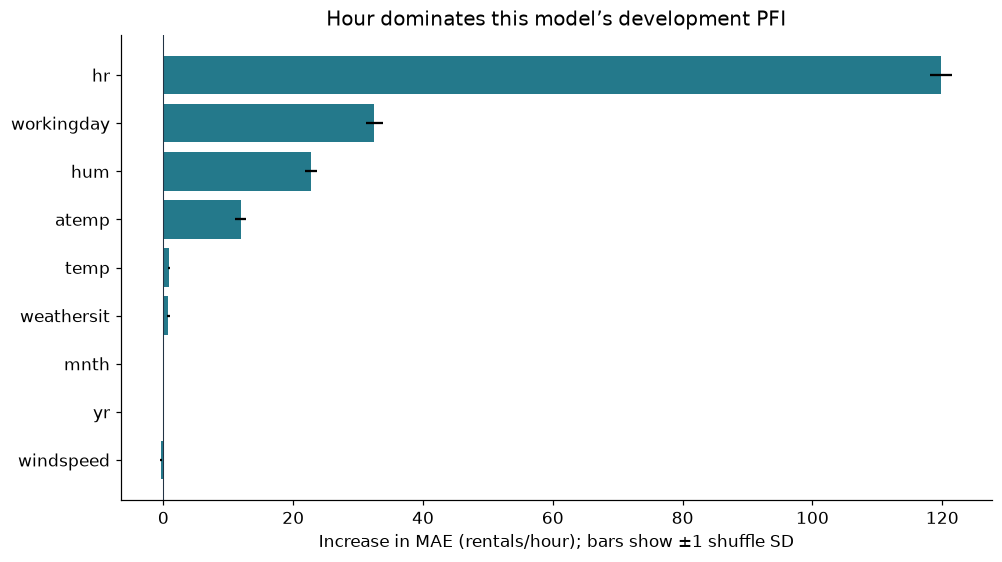

|  | mean | shuffle_sd |
| --- | --- | --- |
| hr | 119.843 | 1.689 |
| workingday | 32.505 | 1.334 |
| hum | 22.781 | 0.893 |
| atemp | 11.888 | 0.903 |
| temp | 0.880 | 0.208 |
| weathersit | 0.776 | 0.203 |
| mnth | 0.012 | 0.004 |
| yr | 0.000 | 0.000 |
| windspeed | -0.307 | 0.164 |

```python
def permutation_runs(columns):
    increases = []
    for permutation in permutations:
        altered = X_dev.copy()
        altered.loc[:,columns] = X_dev.iloc[permutation][columns].to_numpy()
        error = mean_absolute_error(y_dev, model.predict(altered))
        increases.append(error-original_mae)
    return np.array(increases)

pfi_runs = {feature: permutation_runs([feature]) for feature in FEATURES}
pfi = pd.DataFrame({'mean': {f:v.mean() for f,v in pfi_runs.items()},
                    'shuffle_sd': {f:v.std(ddof=1) for f,v in pfi_runs.items()}})
ordered = pfi.sort_values('mean')
fig, ax = plt.subplots(figsize=(9,5), layout='constrained')
ax.barh(ordered.index, ordered['mean'], xerr=ordered['shuffle_sd'], color=TEAL)
ax.axvline(0, color=INK, linewidth=.7)
ax.set(title='Hour dominates this model’s development PFI',
       xlabel='Increase in MAE (rentals/hour); bars show ±1 shuffle SD')
show_figure(fig,'01_permutation_importance')
display(pfi.sort_values('mean',ascending=False).round(3))
pd.DataFrame(pfi_runs).to_csv(OUTPUTS/'individual_permutation_runs.csv',index=False)
```

**Notice:** hour produces the largest MAE increase, followed by working-day status and humidity. Importance describes this fitted model, metric, perturbation protocol, and evaluation population. A large score is not a causal effect or a direction of change.

Unrestricted row shuffling can break temporal and other dependencies. The plotted SD describes variability across ten shuffles with a fixed dataset/model; it is not a confidence interval for the population.

**Mini-investigation:** year has zero PFI. Does that prove the model ignores year? Inspect the next output before answering.

```python
display(pd.DataFrame({'train_year_counts': train.yr.value_counts(),
                      'development_year_counts': development.yr.value_counts()}).fillna(0).astype(int))
assert X_dev.yr.nunique() == 1
print('Shuffling a constant development column leaves its values unchanged.')
```

| yr | train_year_counts | development_year_counts |
| --- | --- | --- |
| 0 | 8645 | 0 |
| 1 | 4358 | 2208 |

```
Shuffling a constant development column leaves its values unchanged.
```

Every development row is from 2012. Zero PFI here cannot establish that year is unused by the trained model. The small negative wind-speed importance likewise does not prove that deleting it would improve a retrained model.

**Transition:** hour matters, but a ranking does not tell us the shape of the model's hourly response.

## 4 · PDP: what does the average response look like?

**Manager:** “Show me how the model's predictions change across the day.”

**Predict first:** is grouping observed rentals by hour the same as computing a PDP?

A Partial Dependence Plot sets the chosen feature to each grid value across a reference sample, predicts for those altered records, and averages. The other columns remain as recorded. We select 400 development rows reproducibly and use those same rows for all PDP/ICE/ALE comparisons.

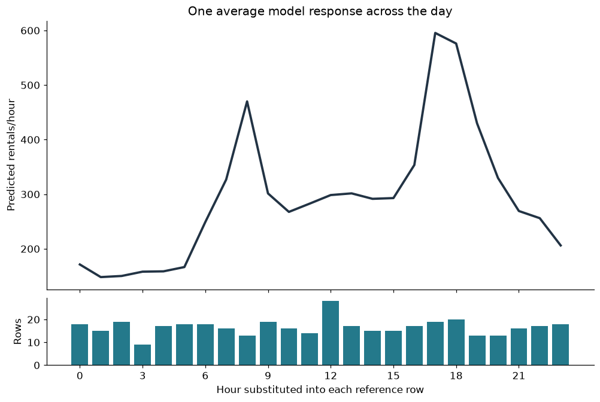

```python
reference = X_dev.sample(n=400, random_state=SEED).sort_index()
reference.index.to_series().to_csv(OUTPUTS/'reference_row_indices.csv',index=False)
hour_grid = np.arange(24)
hour_columns = []
for hour in hour_grid:
    altered = reference.copy()
    altered['hr'] = hour
    hour_columns.append(model.predict(altered))

# Each row holds predictions for one original record over the hour grid.
hour_ice = np.column_stack(hour_columns)
hour_pdp = hour_ice.mean(axis=0)
assert hour_ice.shape == (400,24)

fig, (ax, density) = plt.subplots(2,1,figsize=(9,6),sharex=True,
    gridspec_kw={'height_ratios':[4,1]},layout='constrained')
ax.plot(hour_grid,hour_pdp,color=INK,lw=2.5)
ax.set(title='One average model response across the day',ylabel='Predicted rentals/hour')
density.bar(hour_grid,reference.hr.value_counts().reindex(hour_grid,fill_value=0),color=TEAL)
density.set(xlabel='Hour substituted into each reference row',ylabel='Rows',xticks=range(0,24,3))
show_figure(fig,'02_hour_pdp')
```

**Interpret:** a point at hour 8 is the mean prediction after assigning hour 8 to all 400 reference rows. It is not the observed mean of records originally taken at 8 a.m.

The sample comes from July–September 2012, so this is not a full-year average. Holding recorded weather fixed while changing hour can also create poorly supported records. Even a familiar peak is model behavior, not proof of commuting motives.

**Transition:** can one line adequately describe the different responses among those rows?

## 5 · ICE: who is hidden by the average?

**Manager:** “Does that line describe working-day and non-working-day records equally well?”

**Predict first:** how would you distinguish different starting prediction levels from different response shapes?

Individual Conditional Expectation (ICE) retains the prediction curve for each reference row. We have already computed it. Centered ICE subtracts each row's prediction at a common reference hour; this makes shape differences easier to compare.

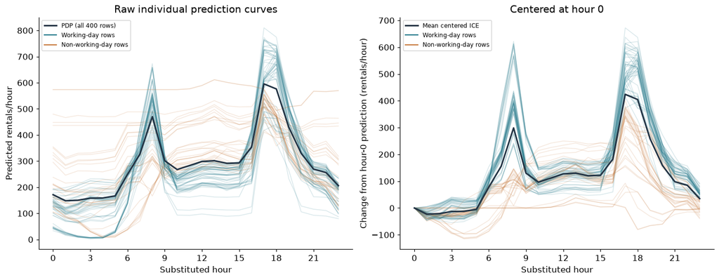

```python
centered_hour_ice = hour_ice-hour_ice[:,[0]]
assert np.allclose(hour_ice.mean(axis=0),hour_pdp)
assert np.allclose(centered_hour_ice[:,0],0)
shown = np.linspace(0,len(reference)-1,80,dtype=int)
is_working = reference.workingday.to_numpy() == 1
fig, axes = plt.subplots(1,2,figsize=(13,5),layout='constrained')
for i in shown:
    color = TEAL if is_working[i] else ORANGE
    axes[0].plot(hour_grid,hour_ice[i],color=color,alpha=.17,lw=1)
    axes[1].plot(hour_grid,centered_hour_ice[i],color=color,alpha=.17,lw=1)
axes[0].plot(hour_grid,hour_pdp,color=INK,lw=2,label='PDP (all 400 rows)')
axes[1].plot(hour_grid,centered_hour_ice.mean(0),color=INK,lw=2,label='Mean centered ICE')
for ax in axes:
    ax.plot([],[],color=TEAL,label='Working-day rows')
    ax.plot([],[],color=ORANGE,label='Non-working-day rows')
    ax.set(xlabel='Substituted hour',xticks=range(0,24,3))
    ax.legend(fontsize=8)
axes[0].set(title='Raw individual prediction curves',ylabel='Predicted rentals/hour')
axes[1].set(title='Centered at hour 0',ylabel='Change from hour-0 prediction (rentals/hour)')
show_figure(fig,'03_hour_ice')
```

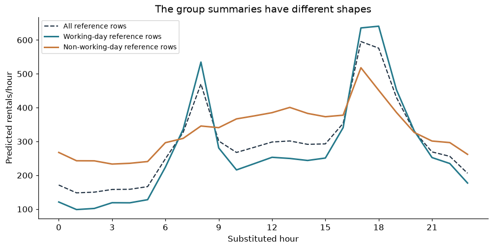

```python
hour_groups = pd.DataFrame({'hour':hour_grid,'all':hour_pdp,
    'working_day':hour_ice[is_working].mean(0),
    'non_working_day':hour_ice[~is_working].mean(0)})
fig,ax=plt.subplots(figsize=(9,4.5),layout='constrained')
ax.plot(hour_grid,hour_pdp,color=INK,ls='--',label='All reference rows')
ax.plot(hour_grid,hour_groups.working_day,color=TEAL,lw=2,label='Working-day reference rows')
ax.plot(hour_grid,hour_groups.non_working_day,color=ORANGE,lw=2,label='Non-working-day reference rows')
ax.set(title='The group summaries have different shapes',xlabel='Substituted hour',
       ylabel='Predicted rentals/hour',xticks=range(0,24,3))
ax.legend(fontsize=9)
show_figure(fig,'04_hour_group_curves')
hour_groups.to_csv(OUTPUTS/'hour_curves.csv',index=False)
```

**Notice:** centering does not make the curves coincide. The model's hourly response varies across records. Working-day reference rows show pronounced morning and evening model peaks; the non-working-day summary has a different shape.

Each line belongs to an altered hourly record, not a person or an observed day. The two group summaries also use different distributions of the other features. Their contrast does not isolate the effect of changing working-day status. ICE reveals heterogeneous model responses; a domain explanation for them needs more evidence.

**Discuss:** what would be lost if the manager saw only the black average line? What could she still misunderstand if she saw all the ICE lines?

## 6 · Temperature: inspect the inputs behind a curve

**Manager:** “What does the model predict as temperature changes?”

**Predict first:** if temperature changes but perceived temperature stays fixed, are the resulting combinations necessarily supported by the data?

We now reuse the same reference rows and model. The helper below packages the explicit replacement-and-prediction loop from the hour example.

```
Training temperature/perceived-temperature correlation: 0.9918
```

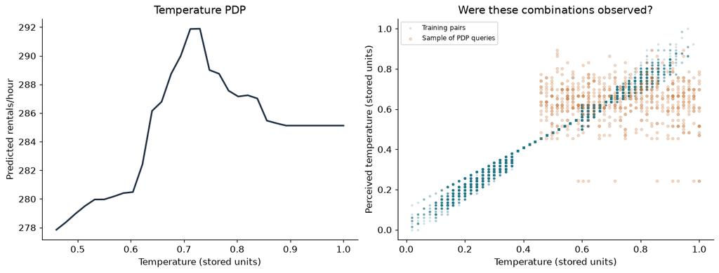

```python
def ice_matrix(predict, rows, feature, grid):
    return np.column_stack([predict(rows.assign(**{feature:value})) for value in grid])

temperature_grid = np.linspace(reference.temp.min(),reference.temp.max(),31)
temperature_ice = ice_matrix(model.predict,reference,'temp',temperature_grid)
temperature_pdp = temperature_ice.mean(axis=0)
correlation = X_train.temp.corr(X_train.atemp)
print(f'Training temperature/perceived-temperature correlation: {correlation:.4f}')

pdp_pairs = pd.concat([reference.assign(temp=value)[['temp','atemp']]
                       for value in temperature_grid],ignore_index=True)
fig,axes=plt.subplots(1,2,figsize=(12,4.5),layout='constrained')
axes[0].plot(temperature_grid,temperature_pdp,color=INK,lw=2)
axes[0].set(title='Temperature PDP',xlabel='Temperature (stored units)',ylabel='Predicted rentals/hour')
axes[1].scatter(X_train.temp,X_train.atemp,s=4,alpha=.15,color=TEAL,label='Training pairs')
overlay=pdp_pairs.sample(n=600,random_state=SEED)
axes[1].scatter(overlay.temp,overlay.atemp,s=9,alpha=.25,color=ORANGE,label='Sample of PDP queries')
axes[1].set(title='Were these combinations observed?',xlabel='Temperature (stored units)',
            ylabel='Perceived temperature (stored units)')
axes[1].legend(fontsize=8)
show_figure(fig,'05_temperature_and_support')
```

The two thermal measurements have a training correlation near 0.992. Changing one independently can create temperature pairs that are unusual relative to the observed data.

We therefore use a **support diagnostic**, not a validity test. For each temperature pair, measure the standardized distance to its nearest distinct training pair. The reference cutoff is the 99th percentile of nearest-neighbor distances among distinct training pairs.

This diagnostic checks only `temp` and `atemp`. It does **not** certify full-row realism, physical possibility, prediction accuracy, or causal validity.

```python
pair_columns = ['temp','atemp']
training_pairs = X_train[pair_columns].drop_duplicates().to_numpy()
pair_scale = X_train[pair_columns].std().to_numpy()
neighbors = NearestNeighbors(n_neighbors=2).fit(training_pairs/pair_scale)
reference_distances = neighbors.kneighbors(training_pairs/pair_scale)[0][:,1]
distance_cutoff = float(np.quantile(reference_distances,.99))

def pair_distances(pairs):
    return neighbors.kneighbors(np.asarray(pairs)/pair_scale,n_neighbors=1)[0][:,0]

original_distances = pair_distances(reference[pair_columns])
pdp_distances = pair_distances(pdp_pairs)
display(pd.DataFrame([
    ['Original reference pairs',len(original_distances),100*np.mean(original_distances>distance_cutoff)],
    ['Temperature PDP queries',len(pdp_distances),100*np.mean(pdp_distances>distance_cutoff)]
],columns=['Query set','Number of queries','Flagged (%)']).round(2))
```

|  | Query set | Number of queries | Flagged (%) |
| --- | --- | --- | --- |
| 0 | Original reference pairs | 400 | 1.50 |
| 1 | Temperature PDP queries | 12400 | 72.19 |

**Interpret:** about 1.5% of the original sample pairs and 72.2% of PDP query pairs exceed this cutoff. That is evidence about the query distribution. It does not mean that 72.2% of predictions are wrong.

**Transition:** can we summarize model changes using smaller temperature substitutions near observed records?

## 7 · ALE: learn one interval, then accumulate

**Manager:** “Can we reduce the distant combinations behind the summary?”

**Predict first:** instead of assigning every temperature to every row, what changes if we take rows in a small temperature interval and predict only at that interval's two edges?

First-order Accumulated Local Effects (ALE) averages those local prediction differences, accumulates them along the temperature axis, and centers the resulting curve. We start by calculating one interval explicitly. Tied quantile edges are merged, so requested and actual bin counts can differ.

```python
requested_bins = 15
edges = np.unique(np.quantile(reference.temp,np.linspace(0,1,requested_bins+1),method='inverted_cdf'))
membership = np.clip(np.searchsorted(edges,reference.temp,side='right')-1,0,len(edges)-2)
middle_bin = (len(edges)-2)//2
within_bin = reference.iloc[np.flatnonzero(membership==middle_bin)].copy()
lower = within_bin.assign(temp=edges[middle_bin])
upper = within_bin.assign(temp=edges[middle_bin+1])
local_differences = model.predict(upper)-model.predict(lower)
display(pd.Series({'lower_edge':edges[middle_bin], 'upper_edge':edges[middle_bin+1],
                   'rows_in_bin':len(within_bin),
                   'mean_prediction_difference':local_differences.mean()},name='One ALE interval'))
```

```
lower_edge                     0.680000
upper_edge                     0.700000
rows_in_bin                   21.000000
mean_prediction_difference     0.948268
Name: One ALE interval, dtype: float64
```

Each row contributes a prediction difference, not a difference between observed rental outcomes. We average within the interval, repeat across intervals, and accumulate. Our numerical implementation linearly interpolates the accumulated endpoint curve and subtracts its empirical mean over reference temperatures.

```python
def ale_1d(predict, X, feature, bins=15):
    """First-order numerical ALE; quantile bins, linear interpolation, empirical centering."""
    # Observed-value quantiles avoid empty slivers caused by interpolating tied values.
    edges = np.unique(np.quantile(X[feature], np.linspace(0, 1, bins + 1), method='inverted_cdf'))
    membership = np.clip(np.searchsorted(edges, X[feature], side='right') - 1, 0, len(edges)-2)
    effects, counts = [], []
    query_pairs = []
    for b in range(len(edges)-1):
        rows = X.iloc[np.flatnonzero(membership == b)].copy()
        if len(rows) == 0:
            raise ValueError('Empty ALE bin; use fewer bins.')
        low, high = rows.copy(), rows.copy()
        low[feature], high[feature] = edges[b], edges[b+1]
        effects.append(float(np.mean(predict(high) - predict(low))))
        counts.append(len(rows))
        query_pairs.extend([low[['temp','atemp']], high[['temp','atemp']]])
    curve = np.r_[0., np.cumsum(effects)]
    curve -= np.mean(np.interp(X[feature], edges, curve))
    return edges, curve, counts, pd.concat(query_pairs)
```

```python
ale_versions={}
for number_of_bins in [10,15,20]:
    ale_versions[number_of_bins] = ale_1d(model.predict,reference,'temp',number_of_bins)
ale_edges,ale_curve,ale_counts,ale_pairs = ale_versions[15]
display(pd.DataFrame({'lower':ale_edges[:-1],'upper':ale_edges[1:],'rows':ale_counts}))
print(f'Requested 15 bins; obtained {len(ale_counts)} populated bins.')

# Independent analytic check of the numerical implementation.
# A known additive function has a known centered temperature component.
known_function = lambda X: 3*X.temp.to_numpy()+2*X.atemp.to_numpy()
known_edges,known_curve,_,_ = ale_1d(known_function,reference,'temp',15)
expected_component = 3*(known_edges-reference.temp.mean())
ale_check_error = float(np.max(np.abs(known_curve-expected_component)))
assert ale_check_error < 1e-10
print(f'Additive-function check, maximum error: {ale_check_error:.2e}')
```

|  | lower | upper | rows |
| --- | --- | --- | --- |
| 0 | 0.46 | 0.54 | 26 |
| 1 | 0.54 | 0.60 | 25 |
| 2 | 0.60 | 0.62 | 23 |
| 3 | 0.62 | 0.64 | 15 |
| 4 | 0.64 | 0.66 | 36 |
| 5 | 0.66 | 0.68 | 34 |
| 6 | 0.68 | 0.70 | 21 |
| 7 | 0.70 | 0.72 | 38 |
| 8 | 0.72 | 0.74 | 41 |
| 9 | 0.74 | 0.76 | 31 |
| 10 | 0.76 | 0.78 | 26 |
| 11 | 0.78 | 0.80 | 18 |
| 12 | 0.80 | 0.86 | 34 |
| 13 | 0.86 | 1.00 | 32 |

```
Requested 15 bins; obtained 14 populated bins.
Additive-function check, maximum error: 4.44e-16
```

The analytic check verifies recovery of a known component in a separate mathematical example. It does not validate the bike model or make observational data causal.

**Predict first:** should an ALE y-value of zero mean that the model predicts zero rentals? Why must we center the PDP before comparing its shape with ALE?

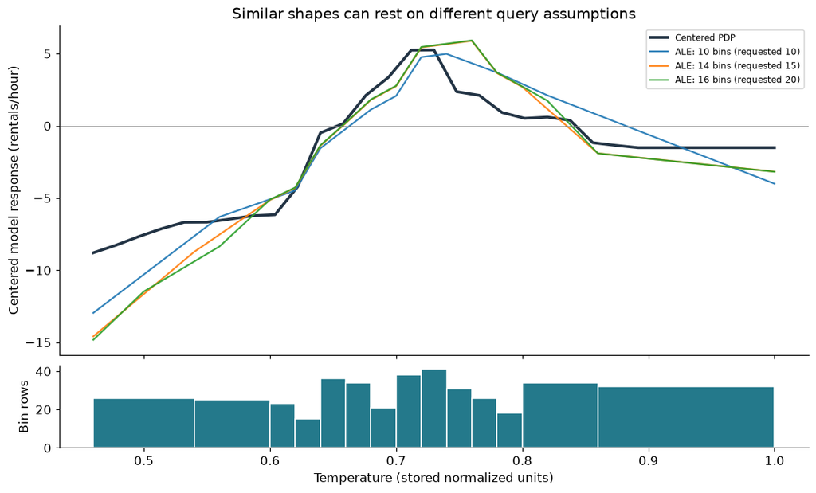

```python
centered_temperature_pdp = temperature_pdp-np.mean(
    np.interp(reference.temp,temperature_grid,temperature_pdp))
fig,(ax,density)=plt.subplots(2,1,figsize=(10,6),sharex=True,
    gridspec_kw={'height_ratios':[4,1]},layout='constrained')
ax.plot(temperature_grid,centered_temperature_pdp,color=INK,lw=2.5,label='Centered PDP')
for requested,(e,curve,counts,_) in ale_versions.items():
    ax.plot(e,curve,label=f'ALE: {len(counts)} bins (requested {requested})',alpha=.9)
ax.axhline(0,color='gray',lw=.6)
ax.set(title='Similar shapes can rest on different query assumptions',
       ylabel='Centered model response (rentals/hour)')
ax.legend(fontsize=8)
density.bar(ale_edges[:-1],ale_counts,width=np.diff(ale_edges),align='edge',color=TEAL,edgecolor='white')
density.set(xlabel='Temperature (stored normalized units)',ylabel='Bin rows')
show_figure(fig,'06_pdp_ale_comparison')
ale_distances = pair_distances(ale_pairs)
```

**Notice:** PDP and ALE have broadly similar shapes here, with local differences. We do not need dramatic disagreement to question their assumptions. The curve comparison also shows sensitivity to binning.

ALE's vertical axis is a centered accumulated model-response component, not an absolute rental forecast. Its local substitutions reduce some extrapolation, but finite bins, sparse observations, and dependencies can still create problematic queries. The bin-count panel helps us identify where evidence is thin.

## 8 · Does the support comparison survive another cutoff?

**Manager:** “Did we get that conclusion only because you chose one distance threshold?”

**Predict first:** when we make the distance threshold larger, should the flagged percentage increase or decrease?

Keep the queries, scaling, and distance definition fixed. Change only the cutoff. Test reference percentiles and, because quantized measurements give nearly identical percentile cutoffs, also test half to twice the original distance radius.

**Percent flagged under each cutoff**

|  | Reference percentile | Distance cutoff | Original pairs | PDP queries | ALE queries |
| --- | --- | --- | --- | --- | --- |
| 0 | 95.0 | 0.1368 | 1.5 | 72.1855 | 9.625 |
| 1 | 97.5 | 0.1368 | 1.5 | 72.1855 | 9.500 |
| 2 | 99.0 | 0.1372 | 1.5 | 72.1855 | 9.500 |
| 3 | 99.5 | 0.1619 | 1.5 | 70.9597 | 7.375 |

|  | Cutoff multiplier | Distance cutoff | Original pairs | PDP queries | ALE queries |
| --- | --- | --- | --- | --- | --- |
| 0 | 0.50 | 0.0686 | 1.75 | 82.4274 | 18.250 |
| 1 | 0.75 | 0.1029 | 1.50 | 75.8387 | 11.375 |
| 2 | 1.00 | 0.1372 | 1.50 | 72.1855 | 9.500 |
| 3 | 1.50 | 0.2058 | 1.50 | 65.2339 | 5.750 |
| 4 | 2.00 | 0.2744 | 1.25 | 57.6210 | 3.625 |

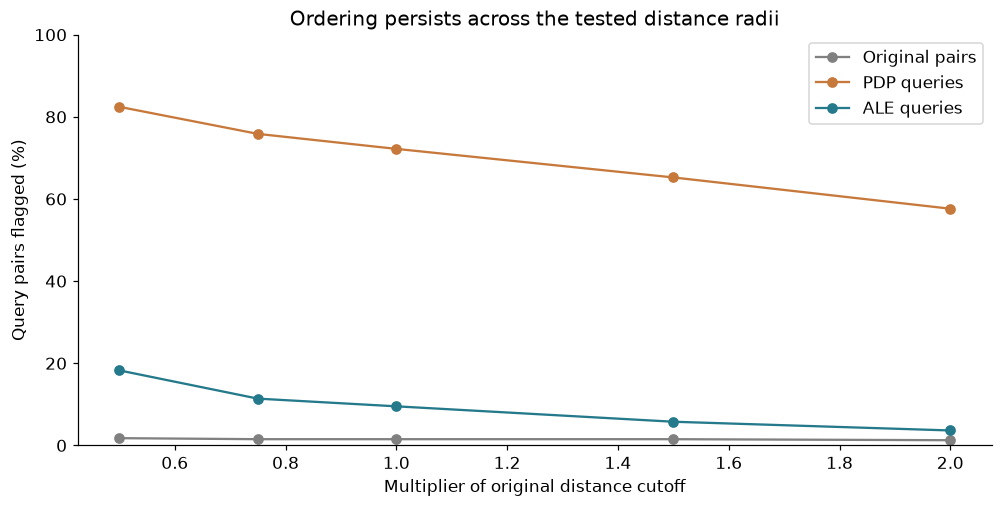

```python
distance_sets={'Original pairs':original_distances,'PDP queries':pdp_distances,'ALE queries':ale_distances}
def flag_row(cutoff):
    return {name:100*np.mean(distances>cutoff) for name,distances in distance_sets.items()}

percentile_rows=[]
for percentile in [95,97.5,99,99.5]:
    cutoff=float(np.quantile(reference_distances,percentile/100))
    percentile_rows.append({'Reference percentile':percentile,'Distance cutoff':cutoff,**flag_row(cutoff)})
radius_rows=[]
for multiplier in [.5,.75,1,1.5,2]:
    cutoff=distance_cutoff*multiplier
    radius_rows.append({'Cutoff multiplier':multiplier,'Distance cutoff':cutoff,**flag_row(cutoff)})
percentile_sensitivity=pd.DataFrame(percentile_rows)
radius_sensitivity=pd.DataFrame(radius_rows)
display(Markdown('**Percent flagged under each cutoff**'))
display(percentile_sensitivity.round(4))
display(radius_sensitivity.round(4))
radius_sensitivity.to_csv(OUTPUTS/'support_radius_sensitivity.csv',index=False)
percentile_sensitivity.to_csv(OUTPUTS/'support_percentile_sensitivity.csv',index=False)

fig,ax=plt.subplots(figsize=(9,4.5),layout='constrained')
for name,color in [('Original pairs','gray'),('PDP queries',ORANGE),('ALE queries',TEAL)]:
    ax.plot(radius_sensitivity['Cutoff multiplier'],radius_sensitivity[name],marker='o',label=name,color=color)
ax.set(title='Ordering persists across the tested distance radii',xlabel='Multiplier of original distance cutoff',
       ylabel='Query pairs flagged (%)',ylim=(0,100))
ax.legend()
show_figure(fig,'07_support_sensitivity')
```

**Defensible conclusion:** ALE has a lower distant-pair flag rate at every tested cutoff in this experiment. At twice the original cutoff, about 57.6% of PDP queries and 3.6% of ALE queries are flagged.

The denominators differ: 400 original pairs, 12,400 PDP queries, and 800 ALE endpoints, with different query construction and weighting. The diagnostic is pairwise and depends on the chosen distance/scaling/reference. These percentages are not invalid-prediction rates or explanation-accuracy scores. The result does not prove ALE universally correct or PDP universally wrong.

**Explain to a partner:** how can PDP and ALE look similar while differing substantially in their queried inputs?

## 9 · Short extension: shared information and group importance

**Manager:** “Temperature had low importance. Does that mean thermal conditions hardly matter?”

**Predict first:** will the importance of the temperature pair equal the sum of the two individual scores?

Joint permutation reassigns both measurements using the same row permutation. That preserves their relationship to each other while changing their relationships to the other columns.

|  | mean | std |
| --- | --- | --- |
| Temperature | 0.880 | 0.208 |
| Perceived temperature | 11.888 | 0.903 |
| Both, jointly | 15.143 | 0.833 |

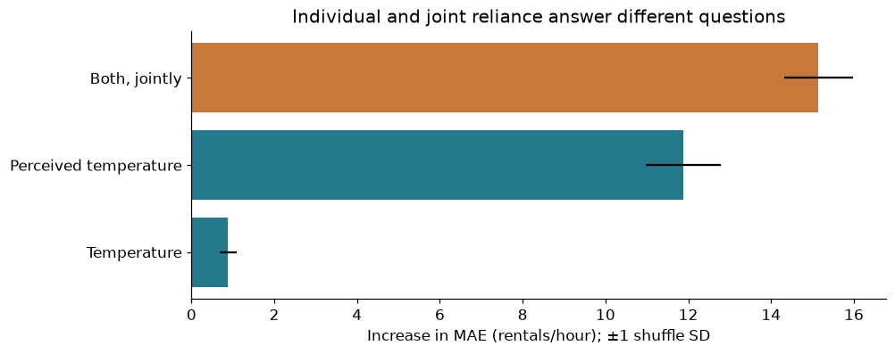

```python
thermal_runs=permutation_runs(['temp','atemp'])
thermal_comparison=pd.DataFrame({
    'Temperature':pfi_runs['temp'],
    'Perceived temperature':pfi_runs['atemp'],
    'Both, jointly':thermal_runs
}).agg(['mean','std']).T
display(thermal_comparison.round(3))
fig,ax=plt.subplots(figsize=(9,3.5),layout='constrained')
ax.barh(thermal_comparison.index,thermal_comparison['mean'],xerr=thermal_comparison['std'],color=[TEAL,TEAL,ORANGE])
ax.set(title='Individual and joint reliance answer different questions',
       xlabel='Increase in MAE (rentals/hour); ±1 shuffle SD')
show_figure(fig,'08_grouped_permutation')
thermal_comparison.to_csv(OUTPUTS/'thermal_group_importance.csv')
```

The fixed model's mean MAE increases are about 0.88 for temperature, 11.89 for perceived temperature, and 15.14 for the pair. The group score is not a unique allocation of credit or a required sum of individual scores.

We can say this model relies more on perceived temperature under the chosen test. Strong dependence makes separate interpretation difficult, but these experiments have not isolated correlation as the cause of the ranking. Group permutation still breaks associations with other inputs. Low individual PFI is not evidence that thermal conditions are unimportant in the world.

## 10 · Final-period evaluation

The data split, model settings, methods, reference-sample rule, and explanation comparisons are fixed. We now evaluate the same model and training baselines on October–December 2012. This period was not used to tune the model or select the displayed explanation examples.

**Predict first:** why might predictive error change in a later season even with the same model? Would a good final score establish that our explanations are faithful or causal?

The next cell records the analysis configuration before scoring. It reports the result without changing the model in response. A future rerun of this completed notebook reproduces an already-observed evaluation; it does not create a fresh holdout.

```python
analysis_config={'seed':SEED,'features':FEATURES,'train_end':'2012-06-30',
    'development_period':['2012-07-01','2012-09-30'],
    'test_period':['2012-10-01','2012-12-31'],
    'model_parameters':model[-1].get_params(),
    'reference_indices':reference.index.tolist(),'permutation_repeats':len(permutations),
    'requested_ale_bins':[10,15,20],'support_reference_percentile':99,
    'data_sha256':data_hash,'versions':versions}
(OUTPUTS/'analysis_config.json').write_text(json.dumps(analysis_config,indent=2))

test = data.loc[test_mask].copy()
X_test,y_test=test[FEATURES],test['cnt']
test_predictions={'Training mean':np.full(len(X_test),training_mean),
                  'Hour/workday mean':calendar_prediction(X_test),
                  'Random Forest':model.predict(X_test)}
test_scores=score_predictions(y_test,test_predictions)
comparison=pd.concat({'Development':dev_scores,'Final period':test_scores},names=['Period','Predictor'])
display(comparison.round(3))
test_scores.to_csv(OUTPUTS/'final_test_metrics.csv')
pd.DataFrame({'timestamp':timestamp.loc[test.index].astype(str),
              'observed_rentals':y_test,**test_predictions}).to_csv(OUTPUTS/'final_test_predictions.csv',index=False)
```

| Period | Predictor | MAE | RMSE | R2 |
| --- | --- | --- | --- | --- |
| Development | Training mean | 197.829 | 260.650 | -0.273 |
|  | Hour/workday mean | 125.538 | 168.551 | 0.468 |
|  | Random Forest | 74.435 | 101.998 | 0.805 |
| Final period | Training mean | 156.565 | 208.056 | -0.065 |
|  | Hour/workday mean | 88.543 | 129.202 | 0.589 |
|  | Random Forest | 67.291 | 99.562 | 0.756 |

**Observed final-period result:** Random Forest MAE is **67.29 rentals/hour**, lower than development MAE (74.44) and lower than the calendar baseline (88.54). Final R² is **0.756**. This evaluates prediction on one later period. It does not test explanation correctness or validate an operational intervention. Seasonal composition, demand levels, and other time changes may contribute; this comparison does not isolate their causes.

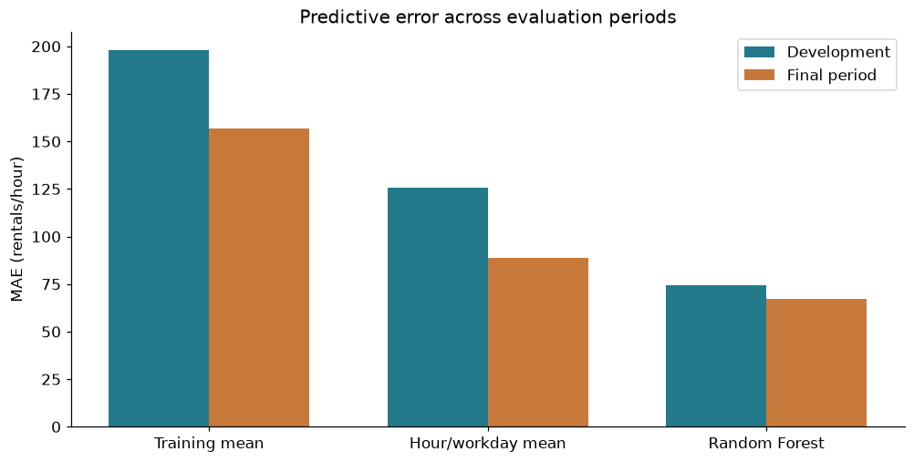

```python
final_mae=float(test_scores.loc['Random Forest','MAE'])
calendar_mae=float(test_scores.loc['Hour/workday mean','MAE'])
change_word='higher' if final_mae>original_mae else 'lower'
comparison_word='lower' if final_mae<calendar_mae else 'higher'
display(Markdown(
    f"**Observed final-period result:** Random Forest MAE is **{final_mae:.2f} rentals/hour**, "
    f"{change_word} than development MAE ({original_mae:.2f}) and {comparison_word} than the "
    f"calendar baseline ({calendar_mae:.2f}). Final R² is **{test_scores.loc['Random Forest','R2']:.3f}**. "
    "This evaluates prediction on one later period. It does not test explanation correctness or "
    "validate an operational intervention. Seasonal composition, demand levels, and other time changes "
    "may contribute; this comparison does not isolate their causes."
))
fig,ax=plt.subplots(figsize=(9,4.5),layout='constrained')
positions=np.arange(len(dev_scores))
ax.bar(positions-.18,dev_scores.MAE,.36,label='Development',color=TEAL)
ax.bar(positions+.18,test_scores.MAE,.36,label='Final period',color=ORANGE)
ax.set(xticks=positions,xticklabels=dev_scores.index,ylabel='MAE (rentals/hour)',
       title='Predictive error across evaluation periods')
ax.legend()
show_figure(fig,'09_final_evaluation')
```

## 11 · Your report to the manager

Write **150–200 words** that include:

1. Three supported findings, each linked to a method or result.
2. Two limitations that change how the explanations should be read.
3. One justified follow-up question before an operational decision.

Include at least one numerical result and name the evaluation period. Explain how the model can have useful predictive performance while its explanations remain assumption-sensitive.

**Check your wording:** “The model's predicted rentals changed when we substituted hour” is supported here. “Changing the hour causes people to rent more” is not. Likewise, distant-pair percentages are diagnostic flags, not error rates.

**Self-check**

- Why does PFI require a performance metric while PDP does not require outcome labels?
- How can zero PFI occur even when a model uses a feature?
- What information disappears when ICE curves are averaged? What does centering remove?
- Why can fixed-feature substitutions make PDP and ICE difficult to interpret?
- What is accumulated and centered in ALE?
- What did the support-cutoff check establish, and what did it leave untested?
- Why need grouped importance not equal the sum of separate importances?

## 12 · What this investigation established

We separated four questions: **what the model relies on**, **how its average prediction changes**, **how those responses differ across records**, and **whether the queried inputs resemble observed combinations**.

For this fixed model, hour dominates development PFI; individual hour responses differ behind the average. The strongly related temperature measurements complicate both importance and feature-effect interpretation. ALE queried fewer distant pairs across the tested cutoffs, even though PDP and ALE had broadly similar shapes. Final-period prediction results add evidence about generalization to one later period, not evidence of causality or explanation truth.

This completes our tabular global-explanation investigation. The same habit—asking what an explanation represents and how it was checked—will carry into image and text cases.

```python
# Save compact, reproducible evidence from this notebook's computations.
pd.DataFrame({'temperature':temperature_grid,'pdp':temperature_pdp,
              'centered_pdp':centered_temperature_pdp}).to_csv(OUTPUTS/'temperature_pdp.csv',index=False)
for requested,(e,curve,counts,_) in ale_versions.items():
    pd.DataFrame({'edge':e,'ale':curve}).to_csv(OUTPUTS/f'ale_temperature_requested_{requested}.csv',index=False)
np.savez_compressed(OUTPUTS/'ice_arrays.npz',hour_grid=hour_grid,hour_ice=hour_ice,
                    temperature_grid=temperature_grid,temperature_ice=temperature_ice)
summary={'development':dev_scores.to_dict(orient='index'),
         'final_test':test_scores.to_dict(orient='index'),
         'pfi':pfi.to_dict(orient='index'),
         'thermal_group':thermal_comparison.to_dict(orient='index'),
         'temperature_correlation':float(correlation),
         'support_radius_sensitivity':radius_sensitivity.to_dict(orient='records'),
         'ale_linear_check_max_error':ale_check_error,
         'ale_actual_bin_counts':{str(n):len(v[2]) for n,v in ale_versions.items()},
         'elapsed_seconds':time.perf_counter()-START,'versions':versions,
         'data_sha256':data_hash,'final_test_evaluated':True}
(OUTPUTS/'notebook_results.json').write_text(json.dumps(summary,indent=2))
print(f'Completed. Results and figures are in {OUTPUTS.name}/.')
```

```
Completed. Results and figures are in outputs/.
```

## References and further reading

- **Data:** Fanaee-T, H. (2013). *Bike Sharing*. UCI Machine Learning Repository. [DOI: 10.24432/C5W894](https://doi.org/10.24432/C5W894). CC BY 4.0. Raw source retained in `data/`; its original README is included. See [the repository](https://archive.ics.uci.edu/dataset/275/bike+sharing+dataset) for metadata. Temperature normalization and season descriptions differ between sources; this notebook preserves stored units and omits season.
- **Course mapping:** supplied *Model-Agnostic Explanation Methods* lecture, pp. 197–240: PDP, ICE, ALE, PFI, dependence, and interpretation boundaries.
- **ICE:** Goldstein, A., Kapelner, A., Bleich, J., & Pitkin, E. (2015). *Peeking Inside the Black Box: Visualizing Statistical Learning With Plots of Individual Conditional Expectation*. [DOI: 10.1080/10618600.2014.907095](https://doi.org/10.1080/10618600.2014.907095).
- **ALE:** Apley, D. W., & Zhu, J. (2020). *Visualizing the Effects of Predictor Variables in Black Box Supervised Learning Models*. [DOI: 10.1111/rssb.12377](https://doi.org/10.1111/rssb.12377); [author preprint](https://arxiv.org/abs/1612.08468).
- **Implementation guidance:** scikit-learn's [PDP/ICE documentation](https://scikit-learn.org/stable/modules/partial_dependence.html) and [permutation importance documentation](https://scikit-learn.org/stable/modules/permutation_importance.html).

Our model choices, support-distance diagnostic, binning sensitivity checks, and teaching narrative are case-specific analyses. They are not prescribed thresholds or guarantees from these sources.